# T.J. Rämö

# Toni J. Rämö

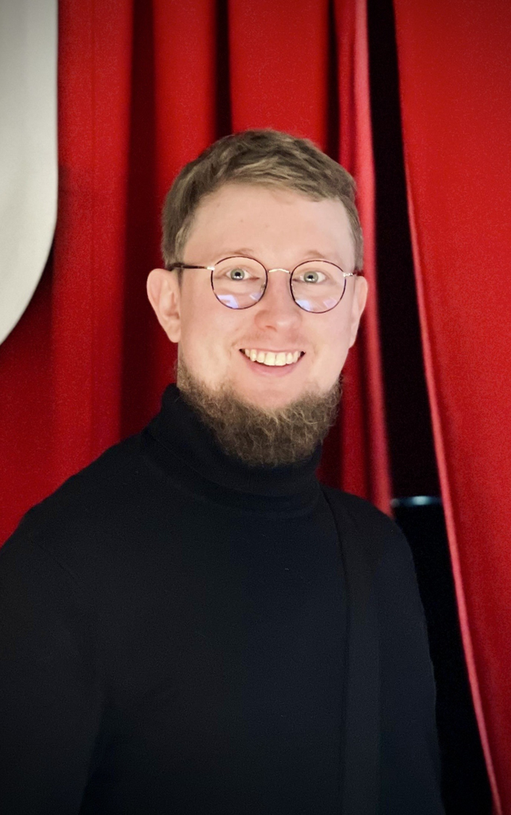

👋 About me  
🎓 Education  
🛠️ Experience  
🚧 Projects

## 👋 About me

- 💻 Solutions Engineer at Gradyent B.V. | District heating analytics & digital twins
- 🎓 MSc x 2 (Data Science, Energy Technology)
- 👨 Dad
- 🐕 Dog owner

**Contact info**:

- ✉️ toni.j.ramo@gmail.com
- 📇 [LinkedIn](https://fi.linkedin.com/in/toniramo)

## 🎓 Education

Master of Science (Data Science)  
**02.2023 – 06.2025** | **University of Helsinki**

- Focusing on machine learning, statistical modeling, and applied data analysis, with hands-on experience in building models, analyzing high-dimensional data, and communicating insights through interactive visualizations.
- Thesis: [*A multi-phase framework for exploring residential block layouts*](https://helda.helsinki.fi/items/f93632c6-f703-4f5e-9633-42da897f6ca7)
- Average grade: **4.7/5.0**.

Bachelor of Science (Computer Science)  
**09.2019 – 02.2023** | **University of Helsinki**

- Studies alongside work and childcare responsibilities.
- Thesis: *Päätöspuut datavirtojen louhinnassa* (Decision trees in data stream mining)
- Average grade: **4.8/5.0**

Master of Science in Technology (Energy Technology)  
**06.2013 – 06.2016** | **Aalto University**

- Major: Energy Economics and Energy Systems for Communities
- Minors: Economics (Industrial Management); Media
- Thesis: *Coal-fired Electricity Generation after Paris 2015 Climate Agreement*
- Other: Exchange studies at DTU, Denmark (01.2014 -– 06.2014).

Bachelor of Science in Technology (Energy Technology)  
**09.2010 – 06.2013** | **Aalto University**

- Major: Energy and HVAC Technology
- Minor: Industrial Management
- Thesis: *Teollinen symbioosi ulkomailla* (Industrial Symbiosis Abroad)
- Other: Volunteered in Student Guild (KIK ry) activities as Graphic Designer (2011), Foreign Minister (2012), and Tutor for exchange students (2012).

## 🛠️ Experience

Solutions Engineer  
**10.2025 – Present** | Gradyent B.V., Espoo (remote via Remote.com)

- Working with district heating utilities to deploy and use a digital twin platform for network analysis and improvement.
- Analysis of operational and geo-spatial data to investigate network performance and identify optimization opportunities.

Research assistant  
**09.2024 – 03.2025** | University of Helsinki, Helsinki

- Thesis: *A multi-phase framework for exploring residential block layouts* (FAIR project, for an architecture firm)
- Built a Grasshopper tool using Python and OR-Tools to automate residential design under regulatory constraints

Content Coordinator  
**11.2020 – 09.2021** | **Leanheat Oy** (Danfoss), Helsinki

- Coordinated and maintained content and visuals for both technical and sales-related materials.
- Worked part-time to allocate time for studies.

Energy Efficiency Expert  
**09.2019 –- 11.2020** | **Leanheat Oy** (Danfoss), Helsinki

- Provided technical support and expertise for key customers as part of the Support and Performance team.
- Maximized the saving potential of customer sites and ensured investment profitability.
- Conducted analyses, generated reports, and delivered trainings.

Test Engineer  
**01.2017 – 08.2019** | **Vaisala Oyj**, Vantaa

- System testing activities in a large-scale R&D project involving the award-winning VaiNet/viewLinc Monitoring System.
- Followed agile practices and collaborated daily with colleagues in North America.

Trainee  
**06.2016 – 01.2017** | **Vaisala Oyj**, Vantaa

- Performed HW and SW testing activities in several R&D projects involving high-end T and RH measurement devices for industrial applications.
- Designed visual materials to support product management and sales.

Research assistant  
**11.2015 – 06.2016** | **Aalto University**, Espoo

- Conducted research for Master’s Thesis.
- Assisted in various course arrangement activities.